# Generating SQL for SQLite using Ollama, ChromaDB

This notebook runs through the process of using the `vanna` Python package to generate SQL using AI (RAG + LLMs) including connecting to a database and training. If you're not ready to train on your own database, you can still try it using a sample SQLite database.

### Which LLM do you want to use?

- OpenAI via Vanna.AI (Recommended)

  Use Vanna.AI for free to generate your queries
- OpenAI

  Use OpenAI with your own API key
- Azure OpenAI

  If you have OpenAI models deployed on Azure
- Ollama

  Use Ollama locally for free. Requires additional setup.
- Mistral via Mistral API

  If you have a Mistral API key
- Other LLM

  If you have a different LLM model

### Where do you want to store the 'training' data?

- Vanna Hosted Vector DB (Recommended)

  Use Vanna.AIs hosted vector database (pgvector) for free. This is usable across machines with no additional setup.
- ChromaDB

  Use ChromaDBs open-source vector database for free locally. No additional setup is necessary -- all database files will be created and stored locally.
- Marqo

  Use Marqo locally for free. Requires additional setup. Or use their hosted option.
- Other VectorDB

  Use any other vector database. Requires additional setup.

## Setup

```python
import warnings
import re

warnings.filterwarnings('ignore', category=DeprecationWarning, message='^Number of requested results')
# warnings.filterwarnings('ignore', category=DeprecationWarning, message=re.escape(r'^Some regex pattern'))

import os

import re
from time import time

from vanna.ollama import Ollama
from vanna.chromadb.chromadb_vector import ChromaDB_VectorStore
```

```python
class MyVanna(ChromaDB_VectorStore, Ollama):
    def __init__(self, config=None):
        ChromaDB_VectorStore.__init__(self, config=config)
        Ollama.__init__(self, config=config)
```

```python
file_db = "~/Downloads/chinook.sqlite"
model_name = "phi3" # 'llama3'

clean_and_train = True  # False
```

```python
config = {
    'model': model_name,   # 'mistral' # "starcoder2"
}
vn = MyVanna(config=config)
```

```python
hostname = os.uname().nodename
print("Hostname:", hostname)
```

```
Hostname: ducklover1
```

```python
file_db = os.path.abspath(os.path.expanduser(file_db))
vn.connect_to_sqlite(file_db)
```

```python
vn.run_sql_is_set
```

```
True
```

```python
def remove_collections(collection_name=None, ACCEPTED_TYPES = ["sql", "ddl", "documentation"]):
    if not collection_name:
        collections = ACCEPTED_TYPES
    elif isinstance(collection_name, str):
        collections = [collection_name]
    elif isinstance(collection_name, list):
        collections = collection_name
    else:
        print(f"\t{collection_name} is unknown: Skipped")
        return

    for c in collections:
        if not c in ACCEPTED_TYPES:
            print(f"\t{c} is unknown: Skipped")
            continue

        # print(f"vn.remove_collection('{c}')")
        vn.remove_collection(c)
```

```python
def strip_brackets(ddl):
    """
    This function removes square brackets from table and column names in a DDL script.

    Args:
        ddl (str): The DDL script containing square brackets.

    Returns:
        str: The DDL script with square brackets removed.
    """
    # Use regular expressions to match and replace square brackets
    pattern = r"\[([^\]]+)]"  # Match any character except ] within square brackets
    return re.sub(pattern, r"\1", ddl)
```

```python
if clean_and_train:
    remove_collections()
```

## Training

### [SQLite sample database](https://www.sqlitetutorial.net/sqlite-sample-database/)

You only need to train once. Do not train again unless you want to add more training data.

```python
df_ddl = vn.run_sql("SELECT type, sql FROM sqlite_master WHERE sql is not null")
```

```python
df_ddl
```

|  | type | sql |
| --- | --- | --- |
| 0 | table | CREATE TABLE "albums"\r\n(\r\n [AlbumId] IN... |
| 1 | table | CREATE TABLE sqlite_sequence(name,seq) |
| 2 | table | CREATE TABLE "artists"\r\n(\r\n [ArtistId] ... |
| 3 | table | CREATE TABLE "customers"\r\n(\r\n [Customer... |
| 4 | table | CREATE TABLE "employees"\r\n(\r\n [Employee... |
| 5 | table | CREATE TABLE "genres"\r\n(\r\n [GenreId] IN... |
| 6 | table | CREATE TABLE "invoices"\r\n(\r\n [InvoiceId... |
| 7 | table | CREATE TABLE "invoice_items"\r\n(\r\n [Invo... |
| 8 | table | CREATE TABLE "media_types"\r\n(\r\n [MediaT... |
| 9 | table | CREATE TABLE "playlists"\r\n(\r\n [Playlist... |
| 10 | table | CREATE TABLE "playlist_track"\r\n(\r\n [Pla... |
| 11 | table | CREATE TABLE "tracks"\r\n(\r\n [TrackId] IN... |
| 12 | index | CREATE INDEX [IFK_AlbumArtistId] ON "albums" (... |
| 13 | index | CREATE INDEX [IFK_CustomerSupportRepId] ON "cu... |
| 14 | index | CREATE INDEX [IFK_EmployeeReportsTo] ON "emplo... |
| 15 | index | CREATE INDEX [IFK_InvoiceCustomerId] ON "invoi... |
| 16 | index | CREATE INDEX [IFK_InvoiceLineInvoiceId] ON "in... |
| 17 | index | CREATE INDEX [IFK_InvoiceLineTrackId] ON "invo... |
| 18 | index | CREATE INDEX [IFK_PlaylistTrackTrackId] ON "pl... |
| 19 | index | CREATE INDEX [IFK_TrackAlbumId] ON "tracks" ([... |
| 20 | index | CREATE INDEX [IFK_TrackGenreId] ON "tracks" ([... |
| 21 | index | CREATE INDEX [IFK_TrackMediaTypeId] ON "tracks... |
| 22 | table | CREATE TABLE sqlite_stat1(tbl,idx,stat) |

```python
if clean_and_train:
    for ddl in df_ddl['sql'].to_list():
        ddl = strip_brackets(ddl)
        vn.train(ddl=ddl)

    # Sometimes you may want to add documentation about your business terminology or definitions.
    vn.train(documentation="In the chinook database invoice means order")
```

```
Adding ddl: CREATE TABLE "albums"
(
    AlbumId INTEGER PRIMARY KEY AUTOINCREMENT NOT NULL,
    Title NVARCHAR(160)  NOT NULL,
    ArtistId INTEGER  NOT NULL,
    FOREIGN KEY (ArtistId) REFERENCES "artists" (ArtistId)
		ON DELETE NO ACTION ON UPDATE NO ACTION
)
Adding ddl: CREATE TABLE sqlite_sequence(name,seq)
Adding ddl: CREATE TABLE "artists"
(
    ArtistId INTEGER PRIMARY KEY AUTOINCREMENT NOT NULL,
    Name NVARCHAR(120)
)
Adding ddl: CREATE TABLE "customers"
(
    CustomerId INTEGER PRIMARY KEY AUTOINCREMENT NOT NULL,
    FirstName NVARCHAR(40)  NOT NULL,
    LastName NVARCHAR(20)  NOT NULL,
    Company NVARCHAR(80),
    Address NVARCHAR(70),
    City NVARCHAR(40),
    State NVARCHAR(40),
    Country NVARCHAR(40),
    PostalCode NVARCHAR(10),
    Phone NVARCHAR(24),
    Fax NVARCHAR(24),
    Email NVARCHAR(60)  NOT NULL,
    SupportRepId INTEGER,
    FOREIGN KEY (SupportRepId) REFERENCES "employees" (EmployeeId)
		ON DELETE NO ACTION ON UPDATE NO ACTION
)
Adding ddl: CREATE TABLE "employees"
(
    EmployeeId INTEGER PRIMARY KEY AUTOINCREMENT NOT NULL,
    LastName NVARCHAR(20)  NOT NULL,
    FirstName NVARCHAR(20)  NOT NULL,
    Title NVARCHAR(30),
    ReportsTo INTEGER,
    BirthDate DATETIME,
```

[output cut: 78 more lines]

```
    FOREIGN KEY (MediaTypeId) REFERENCES "media_types" (MediaTypeId)
		ON DELETE NO ACTION ON UPDATE NO ACTION
)
Adding ddl: CREATE INDEX IFK_AlbumArtistId ON "albums" (ArtistId)
Adding ddl: CREATE INDEX IFK_CustomerSupportRepId ON "customers" (SupportRepId)
Adding ddl: CREATE INDEX IFK_EmployeeReportsTo ON "employees" (ReportsTo)
Adding ddl: CREATE INDEX IFK_InvoiceCustomerId ON "invoices" (CustomerId)
Adding ddl: CREATE INDEX IFK_InvoiceLineInvoiceId ON "invoice_items" (InvoiceId)
Adding ddl: CREATE INDEX IFK_InvoiceLineTrackId ON "invoice_items" (TrackId)
Adding ddl: CREATE INDEX IFK_PlaylistTrackTrackId ON "playlist_track" (TrackId)
Adding ddl: CREATE INDEX IFK_TrackAlbumId ON "tracks" (AlbumId)
Adding ddl: CREATE INDEX IFK_TrackGenreId ON "tracks" (GenreId)
Adding ddl: CREATE INDEX IFK_TrackMediaTypeId ON "tracks" (MediaTypeId)
Adding ddl: CREATE TABLE sqlite_stat1(tbl,idx,stat)
Adding documentation....
```

```python
# show training data
training_data = vn.get_training_data()
training_data
```

|  | id | question | content | training_data_type |
| --- | --- | --- | --- | --- |
| 0 | 039f9d54-59f7-5f29-8c04-14dbc3e95671-ddl | None | CREATE TABLE "artists"\r\n(\r\n ArtistId IN... | ddl |
| 1 | 0db84e3d-ef41-563c-803e-21c1b985dc19-ddl | None | CREATE TABLE "invoices"\r\n(\r\n InvoiceId ... | ddl |
| 2 | 10cba811-ddba-5042-9e90-d764dfcd1629-ddl | None | CREATE INDEX IFK_InvoiceCustomerId ON "invoice... | ddl |
| 3 | 2c711317-b93d-5f60-a728-cb1c6fcbc040-ddl | None | CREATE INDEX IFK_CustomerSupportRepId ON "cust... | ddl |
| 4 | 37319c81-65f7-50ee-956b-795de244bee5-ddl | None | CREATE TABLE sqlite_stat1(tbl,idx,stat) | ddl |
| 5 | 40bd77cd-e1de-5872-8693-624117ff413c-ddl | None | CREATE INDEX IFK_InvoiceLineInvoiceId ON "invo... | ddl |
| 6 | 41130543-7164-562a-90a7-0fd0a409c154-ddl | None | CREATE TABLE "albums"\r\n(\r\n AlbumId INTE... | ddl |
| 7 | 458debc8-8082-5450-a17a-66028bd55ace-ddl | None | CREATE TABLE "playlists"\r\n(\r\n PlaylistI... | ddl |
| 8 | 4815f3fd-925b-53ce-9dfa-0e4285d5abd3-ddl | None | CREATE TABLE "invoice_items"\r\n(\r\n Invoi... | ddl |
| 9 | 48d484e9-984c-58ff-b391-75521c69d486-ddl | None | CREATE INDEX IFK_PlaylistTrackTrackId ON "play... | ddl |
| 10 | 551e1120-a6ee-554f-8b8a-ccf4f22d3636-ddl | None | CREATE INDEX IFK_AlbumArtistId ON "albums" (Ar... | ddl |
| 11 | 5ff4911e-45c1-5a59-9566-243a9b6a3320-ddl | None | CREATE TABLE "employees"\r\n(\r\n EmployeeI... | ddl |
| 12 | 65df0648-bf05-5f75-9365-c21f54b2302d-ddl | None | CREATE TABLE "media_types"\r\n(\r\n MediaTy... | ddl |
| 13 | 6b585176-e66d-5b23-8d86-ca8a80e3af3d-ddl | None | CREATE INDEX IFK_EmployeeReportsTo ON "employe... | ddl |
| 14 | 868758b8-e018-55e7-8cc3-75c0e6d211c8-ddl | None | CREATE INDEX IFK_TrackAlbumId ON "tracks" (Alb... | ddl |
| 15 | 9ea4613d-c1be-5a77-ada9-c54ee3f0cab7-ddl | None | CREATE INDEX IFK_TrackMediaTypeId ON "tracks" ... | ddl |
| 16 | a9c9a852-608d-5ef2-aede-26ba098d83d1-ddl | None | CREATE INDEX IFK_TrackGenreId ON "tracks" (Gen... | ddl |
| 17 | b42cc9e1-9219-5a42-9a06-de906f76239e-ddl | None | CREATE TABLE "tracks"\r\n(\r\n TrackId INTE... | ddl |
| 18 | c387b9d2-5ff4-5a07-8364-f5dab45bb2a9-ddl | None | CREATE TABLE "genres"\r\n(\r\n GenreId INTE... | ddl |
| 19 | d654f328-dc36-549e-84c3-06ee0db7e0f7-ddl | None | CREATE TABLE "playlist_track"\r\n(\r\n Play... | ddl |
| 20 | d93f0d68-023d-5afb-8121-ba346699d318-ddl | None | CREATE TABLE "customers"\r\n(\r\n CustomerI... | ddl |
| 21 | e5879308-329e-543f-a693-0c14e2f9972e-ddl | None | CREATE INDEX IFK_InvoiceLineTrackId ON "invoic... | ddl |
| 22 | ea84418b-1a28-59b4-a1f4-2fb674208adc-ddl | None | CREATE TABLE sqlite_sequence(name,seq) | ddl |
| 0 | 2b4dda0a-a6ac-5e34-8f76-e41c0734d55e-doc | None | In the chinook database invoice means order | documentation |

## Asking the AI

Whenever you ask a new question, it will find the 10 most relevant pieces of training data and use it as part of the LLM prompt to generate the SQL.

```python
ts_start = time()
```

[output not shown]

```
Number of requested results 10 is greater than number of elements in index 1, updating n_results = 1
```

[output not shown]

[figure not shown]

```
('\nPRAGMA table_info',
 Empty DataFrame
 Columns: [cid, name, type, notnull, dflt_value, pk]
 Index: [],
 Figure({
     'data': [],
     'layout': {'barmode': 'group',
                'legend': {'tracegroupgap': 0},
                'template': '...',
                'title': {'text': 'Not null values in SQLite Tables'},
                'xaxis': {'anchor': 'y', 'domain': [0.0, 1.0], 'title': {'text': 'cid'}},
                'yaxis': {'anchor': 'x', 'domain': [0.0, 1.0], 'title': {'text': 'notnull'}}}
 }))
```

```python
vn.ask(question="Can you list all tables in the SQLite database catalog?")
```

```python
vn.ask(question="which table stores customer's orders")
```

```
Number of requested results 10 is greater than number of elements in index 1, updating n_results = 1
```

[output not shown]

```
Number of requested results 10 is greater than number of elements in index 1, updating n_results = 1
```

[output not shown]

[figure not shown]

```
('-- SQL to find out how many unique customer records exist in the database:\nSELECT COUNT(DISTINCT CustomerId) AS CustomerCount FROM "customers"',
    CustomerCount
 0             59,
 Figure({
     'data': [{'hovertemplate': 'variable=CustomerCount<br>index=%{x}<br>value=%{y}<extra></extra>',
               'legendgroup': 'CustomerCount',
               'line': {'color': '#636efa', 'dash': 'solid'},
               'marker': {'symbol': 'circle'},
               'mode': 'lines',
               'name': 'CustomerCount',
               'orientation': 'v',
               'showlegend': True,
               'type': 'scatter',
               'x': array([0]),
               'xaxis': 'x',
               'y': array([59]),
               'yaxis': 'y'}],
     'layout': {'legend': {'title': {'text': 'variable'}, 'tracegroupgap': 0},
                'margin': {'t': 60},
                'template': '...',
                'xaxis': {'anchor': 'y', 'domain': [0.0, 1.0], 'title': {'text': 'index'}},
                'yaxis': {'anchor': 'x', 'domain': [0.0, 1.0], 'title': {'text': 'value'}}}
 }))
```

```python
vn.ask(question="How many customers are there")
```

```python
vn.ask(question="what are the top 5 countries that customers come from?")
```

```
Number of requested results 10 is greater than number of elements in index 1, updating n_results = 1
Number of requested results 10 is greater than number of elements in index 1, updating n_results = 1
```

[output not shown]

### More SQL questions

see `sample-sql-queries-sqlite-chinook.ipynb`

```
Number of requested results 10 is greater than number of elements in index 1, updating n_results = 1
Number of requested results 10 is greater than number of elements in index 1, updating n_results = 1
```

[output not shown]

[figure not shown]

[output not shown]

[output cut: 2952 more lines]

```
     'layout': {'barmode': 'relative',
                'legend': {'title': {'text': 'ArtistName'}, 'tracegroupgap': 0},
                'margin': {'t': 60},
                'template': '...',
                'xaxis': {'anchor': 'y', 'domain': [0.0, 1.0], 'title': {'text': 'Title'}},
                'yaxis': {'anchor': 'x',
                          'categoryarray': [Philip Glass Ensemble, Nash Ensemble,
                                            C. Monteverdi, Nigel Rogers -
                                            Chiaroscuro; London Baroque; London
                                            Cornett & Sackbu, ..., Aerosmith,
                                            Accept, AC/DC],
                          'categoryorder': 'array',
                          'domain': [0.0, 1.0],
                          'title': {'text': 'ArtistName'}}}
 }))
```

```python
question = """
    List all albums and their corresponding artist names
"""

vn.ask(question=question)
```

```python
question = """
    Find all tracks with a name containing "What" (case-insensitive)
"""

vn.ask(question=question)
```

```
Number of requested results 10 is greater than number of elements in index 2, updating n_results = 2
Number of requested results 10 is greater than number of elements in index 1, updating n_results = 1
```

[output not shown]

```python
question = """
    Get the total number of invoices for each customer
"""

vn.ask(question=question)
```

```
Number of requested results 10 is greater than number of elements in index 2, updating n_results = 2
Number of requested results 10 is greater than number of elements in index 1, updating n_results = 1
```

[output not shown]

```
Number of requested results 10 is greater than number of elements in index 2, updating n_results = 2
Number of requested results 10 is greater than number of elements in index 1, updating n_results = 1
```

[output not shown]

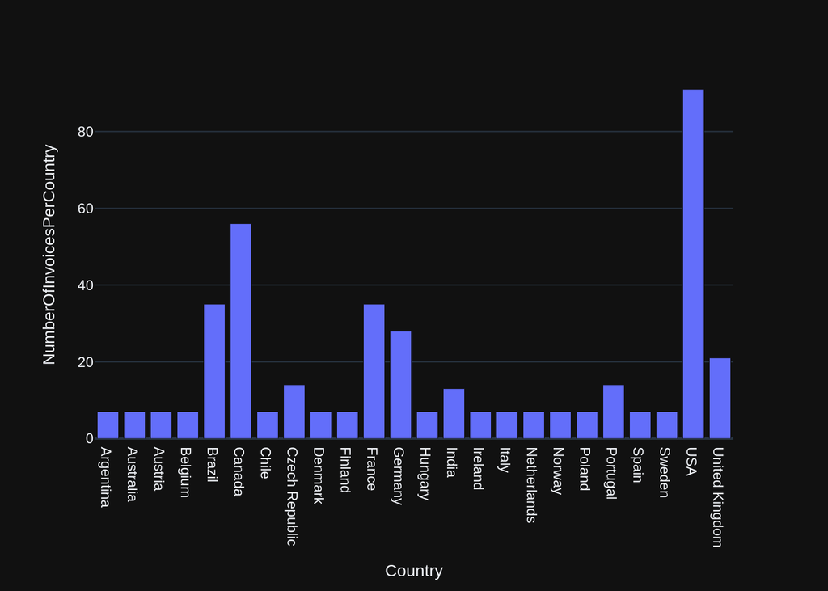

```
('-- SQL to find out how many unique invoices exist for each country based on customer information and also join with customers table as needed\nSELECT c.Country, COUNT(DISTINCT i.InvoiceId) AS NumberOfInvoicesPerCountry\nFROM "invoices" i\nJOIN "customers" c ON i.CustomerId = c.CustomerId\nGROUP BY…
            Country  NumberOfInvoicesPerCountry
 0        Argentina                           7
 1        Australia                           7
 2          Austria                           7
 3          Belgium                           7
 4           Brazil                          35
 5           Canada                          56
 6            Chile                           7
 7   Czech Republic                          14
 8          Denmark                           7
 9          Finland                           7
 10          France                          35
 11         Germany                          28
 12         Hungary                           7
 13           India                          13
 14         Ireland                           7
 15           Italy                           7
 16     Netherlands                           7
 17          Norway                           7
 18          Poland                           7
 19        Portugal                          14
 20           Spain                           7
 21          Sweden                           7
 22             USA                          91
 23  United Kingdom                          21,
 Figure({
     'data': [{'alignmentgroup': 'True',
               'hovertemplate': 'Country=%{x}<br>NumberOfInvoicesPerCountry=%{y}<extra></extra>',
               'legendgroup': '',
               'marker': {'color': '#636efa', 'pattern': {'shape': ''}},
               'name': '',
               'offsetgroup': '',
               'orientation': 'v',
               'showlegend': False,
               'textposition': 'auto',
               'type': 'bar',
               'x': array(['Argentina', 'Australia', 'Austria', 'Belgium', 'Brazil', 'Canada',
                           'Chile', 'Czech Republic', 'Denmark', 'Finland', 'France', 'Germany',
                           'Hungary', 'India', 'Ireland', 'Italy', 'Netherlands', 'Norway',
                           'Poland', 'Portugal', 'Spain', 'Sweden', 'USA', 'United Kingdom'],
                          dtype=object),
               'xaxis': 'x',
               'y': array([ 7,  7,  7,  7, 35, 56,  7, 14,  7,  7, 35, 28,  7, 13,  7,  7,  7,  7,
                            7, 14,  7,  7, 91, 21]),
               'yaxis': 'y'}],
     'layout': {'barmode': 'relative',
                'legend': {'tracegroupgap': 0},
                'margin': {'t': 60},
                'template': '...',
                'xaxis': {'anchor': 'y', 'domain': [0.0, 1.0], 'title': {'text': 'Country'}},
                'yaxis': {'anchor': 'x', 'domain': [0.0, 1.0], 'title': {'text': 'NumberOfInvoicesPerCountry'}}}
 }))
```

```python
question = """
    Find the total number of invoices per country:
"""

vn.ask(question=question)
```

```
Number of requested results 10 is greater than number of elements in index 3, updating n_results = 3
Number of requested results 10 is greater than number of elements in index 1, updating n_results = 1
```

[output not shown]

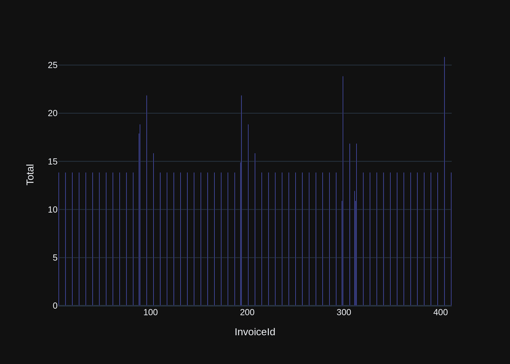

```
('SELECT * FROM "invoices" WHERE Total > 10',
     InvoiceId  CustomerId          InvoiceDate             BillingAddress  \
 0           5          23  2009-01-11 00:00:00            69 Salem Street
 1          12           2  2009-02-11 00:00:00    Theodor-Heuss-Straße 34
 2          19          40  2009-03-14 00:00:00             8, Rue Hanovre
 3          26          19  2009-04-14 00:00:00            1 Infinite Loop
 4          33          57  2009-05-15 00:00:00            Calle Lira, 198
 ..        ...         ...                  ...                        ...
 59        383          10  2013-08-12 00:00:00  Rua Dr. Falcão Filho, 155
 60        390          48  2013-09-12 00:00:00      Lijnbaansgracht 120bg
 61        397          27  2013-10-13 00:00:00            1033 N Park Ave
 62        404           6  2013-11-13 00:00:00              Rilská 3174/6
 63        411          44  2013-12-14 00:00:00            Porthaninkatu 9

    BillingCity BillingState  BillingCountry BillingPostalCode  Total
 0       Boston           MA             USA              2113  13.86
 1    Stuttgart         None         Germany             70174  13.86
 2        Paris         None          France             75002  13.86
 3    Cupertino           CA             USA             95014  13.86
 4     Santiago         None           Chile              None  13.86
 ..         ...          ...             ...               ...    ...
 59   São Paulo           SP          Brazil         01007-010  13.86
 60   Amsterdam           VV     Netherlands              1016  13.86
 61      Tucson           AZ             USA             85719  13.86
 62      Prague         None  Czech Republic             14300  25.86
 63    Helsinki         None         Finland             00530  13.86

 [64 rows x 9 columns],
 Figure({
     'data': [{'alignmentgroup': 'True',
               'hovertemplate': 'InvoiceId=%{x}<br>Total=%{y}<extra></extra>',
               'legendgroup': '',
               'marker': {'color': '#636efa', 'pattern': {'shape': ''}},
               'name': '',
               'offsetgroup': '',
               'orientation': 'v',
               'showlegend': False,
               'textposition': 'auto',
               'type': 'bar',
               'x': array([  5,  12,  19,  26,  33,  40,  47,  54,  61,  68,  75,  82,  88,  89,
                            96, 103, 110, 117, 124, 131, 138, 145, 152, 159, 166, 173, 180, 187,
                           193, 194, 201, 208, 215, 222, 229, 236, 243, 250, 257, 264, 271, 278,
                           285, 292, 298, 299, 306, 311, 312, 313, 320, 327, 334, 341, 348, 355,
                           362, 369, 376, 383, 390, 397, 404, 411]),
               'xaxis': 'x',
               'y': array([13.86, 13.86, 13.86, 13.86, 13.86, 13.86, 13.86, 13.86, 13.86, 13.86,
                           13.86, 13.86, 17.91, 18.86, 21.86, 15.86, 13.86, 13.86, 13.86, 13.86,
                           13.86, 13.86, 13.86, 13.86, 13.86, 13.86, 13.86, 13.86, 14.91, 21.86,
                           18.86, 15.86, 13.86, 13.86, 13.86, 13.86, 13.86, 13.86, 13.86, 13.86,
                           13.86, 13.86, 13.86, 13.86, 10.91, 23.86, 16.86, 11.94, 10.91, 16.86,
                           13.86, 13.86, 13.86, 13.86, 13.86, 13.86, 13.86, 13.86, 13.86, 13.86,
                           13.86, 13.86, 25.86, 13.86]),
               'yaxis': 'y'}],
     'layout': {'barmode': 'relative',
                'legend': {'tracegroupgap': 0},
                'margin': {'t': 60},
                'template': '...',
                'xaxis': {'anchor': 'y', 'domain': [0.0, 1.0], 'title': {'text': 'InvoiceId'}},
                'yaxis': {'anchor': 'x', 'domain': [0.0, 1.0], 'title': {'text': 'Total'}}}
 }))
```

```python
question = """
    List all invoices with a total exceeding $10:
"""

vn.ask(question=question)
```

```
Number of requested results 10 is greater than number of elements in index 4, updating n_results = 4
Number of requested results 10 is greater than number of elements in index 1, updating n_results = 1
```

[output not shown]

[output cut: 18 more lines]

````
324            USA             53703   3.96     1879.14
325         Canada           M6J 1V1   5.94     1879.14
326       Portugal              None   8.91     1879.14
327        Finland             00530  13.86     1879.14
328          India            110017   1.99     1879.14

[329 rows x 10 columns]
Info: Ollama parameters:
model=phi3:latest,
options={},
keep_alive=None
Info: Prompt Content:
[{"role": "system", "content": "The following is a pandas DataFrame that contains the results of the query that answers the question the user asked: '  \n    Find all invoices since 2010 and the total amount invoiced:\n'\n\nThe DataFrame was produced using this query: SELECT *, SUM(Total) OVER() AS …
Info: Ollama Response:
{'model': 'phi3:latest', 'created_at': '2024-08-01T23:26:36.1140955Z', 'message': {'role': 'assistant', 'content': '```python\nimport plotly.graph_objects as go\n\n# Assuming df has a column named InvoiceId which we can sort by and then create a line chart using it for time series visualization.\ndf…
````

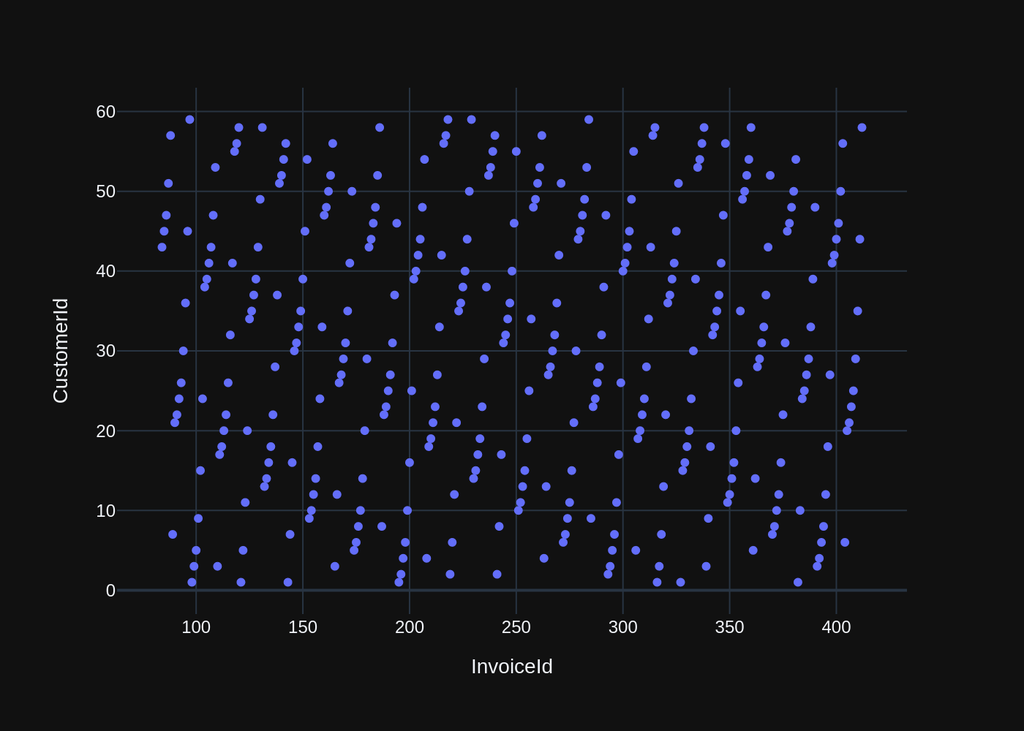

```
('SELECT *, SUM(Total) OVER() AS GrandTotal\nFROM "invoices"\nWHERE InvoiceDate >= \'2010-01-01\' AND Total IS NOT NULL',
      InvoiceId  CustomerId          InvoiceDate  \
 0           84          43  2010-01-08 00:00:00
 1           85          45  2010-01-08 00:00:00
 2           86          47  2010-01-09 00:00:00
 3           87          51  2010-01-10 00:00:00
 4           88          57  2010-01-13 00:00:00
 ..         ...         ...                  ...
 324        408          25  2013-12-05 00:00:00
 325        409          29  2013-12-06 00:00:00
 326        410          35  2013-12-09 00:00:00
 327        411          44  2013-12-14 00:00:00
 328        412          58  2013-12-22 00:00:00

                                BillingAddress BillingCity BillingState  \
 0                            68, Rue Jouvence       Dijon         None
 1                           Erzsébet krt. 58.    Budapest         None
 2                      Via Degli Scipioni, 43        Rome           RM
 3                                 Celsiusg. 9   Stockholm         None
 4                             Calle Lira, 198    Santiago         None
 ..                                        ...         ...          ...
 324                     319 N. Frances Street     Madison           WI
 325                    796 Dundas Street West     Toronto           ON
 326  Rua dos Campeões Europeus de Viena, 4350       Porto         None
 327                           Porthaninkatu 9    Helsinki         None
 328                       12,Community Centre       Delhi         None

     BillingCountry BillingPostalCode  Total  GrandTotal
 0           France             21000   1.98     1879.14
 1          Hungary            H-1073   1.98     1879.14
 2            Italy             00192   3.96     1879.14
 3           Sweden             11230   6.94     1879.14
 4            Chile              None  17.91     1879.14
 ..             ...               ...    ...         ...
 324            USA             53703   3.96     1879.14
 325         Canada           M6J 1V1   5.94     1879.14
 326       Portugal              None   8.91     1879.14
 327        Finland             00530  13.86     1879.14
 328          India            110017   1.99     1879.14

 [329 rows x 10 columns],
 Figure({
     'data': [{'hovertemplate': 'InvoiceId=%{x}<br>CustomerId=%{y}<extra></extra>',
               'legendgroup': '',
               'marker': {'color': '#636efa', 'symbol': 'circle'},
               'mode': 'markers',
               'name': '',
               'orientation': 'v',
               'showlegend': False,
               'type': 'scatter',
               'x': array([ 84,  85,  86, ..., 410, 411, 412]),
               'xaxis': 'x',
               'y': array([43, 45, 47, ..., 35, 44, 58]),
               'yaxis': 'y'}],
     'layout': {'legend': {'tracegroupgap': 0},
                'margin': {'t': 60},
                'template': '...',
                'xaxis': {'anchor': 'y', 'domain': [0.0, 1.0], 'title': {'text': 'InvoiceId'}},
                'yaxis': {'anchor': 'x', 'domain': [0.0, 1.0], 'title': {'text': 'CustomerId'}}}
 }))
```

```python
question = """
    Find all invoices since 2010 and the total amount invoiced:
"""

vn.ask(question=question)
```

```
Number of requested results 10 is greater than number of elements in index 5, updating n_results = 5
Number of requested results 10 is greater than number of elements in index 1, updating n_results = 1
```

````
SQL Prompt: [{'role': 'system', 'content': 'You are a SQLite expert. Please help to generate a SQL query to answer the question. Your response should ONLY be based on the given context and follow the response guidelines and format instructions. \n===Tables \nCREATE INDEX IFK_EmployeeReportsTo ON "em…
Info: Ollama parameters:
model=phi3:latest,
options={},
keep_alive=None
Info: Prompt Content:
[{"role": "system", "content": "You are a SQLite expert. Please help to generate a SQL query to answer the question. Your response should ONLY be based on the given context and follow the response guidelines and format instructions. \n===Tables \nCREATE INDEX IFK_EmployeeReportsTo ON \"employees\" (…
Info: Ollama Response:
{'model': 'phi3:latest', 'created_at': '2024-08-01T23:27:18.401665581Z', 'message': {'role': 'assistant', 'content': 'SELECT e1.FirstName, e1.LastName as \'EmployeeName\', COALESCE(e2.FirstName || \' \' || e2.LastName, \'No Manager\') AS \'ManagerName\'\nFROM "employees" e1\nLEFT JOIN employees e2 O…
LLM Response: SELECT e1.FirstName, e1.LastName as 'EmployeeName', COALESCE(e2.FirstName || ' ' || e2.LastName, 'No Manager') AS 'ManagerName'
FROM "employees" e1
LEFT JOIN employees e2 ON e1.ReportsTo = e2.EmployeeId;
Info: Output from LLM: SELECT e1.FirstName, e1.LastName as 'EmployeeName', COALESCE(e2.FirstName || ' ' || e2.LastName, 'No Manager') AS 'ManagerName'
FROM "employees" e1
LEFT JOIN employees e2 ON e1.ReportsTo = e2.EmployeeId;
Extracted SQL: SELECT e1.FirstName, e1.LastName as 'EmployeeName', COALESCE(e2.FirstName || ' ' || e2.LastName, 'No Manager') AS 'ManagerName'
FROM "employees" e1
LEFT JOIN employees e2 ON e1.ReportsTo = e2.EmployeeId
SELECT e1.FirstName, e1.LastName as 'EmployeeName', COALESCE(e2.FirstName || ' ' || e2.LastName, 'No Manager') AS 'ManagerName'
FROM "employees" e1
LEFT JOIN employees e2 ON e1.ReportsTo = e2.EmployeeId
  FirstName EmployeeName       ManagerName
0    Andrew        Adams        No Manager
1     Nancy      Edwards      Andrew Adams
2      Jane      Peacock     Nancy Edwards
3  Margaret         Park     Nancy Edwards
4     Steve      Johnson     Nancy Edwards
5   Michael     Mitchell      Andrew Adams
6    Robert         King  Michael Mitchell
7     Laura     Callahan  Michael Mitchell
Info: Ollama parameters:
model=phi3:latest,
options={},
keep_alive=None
Info: Prompt Content:
[{"role": "system", "content": "The following is a pandas DataFrame that contains the results of the query that answers the question the user asked: '  \n    List all employees and their reporting manager's name (if any):\n'\n\nThe DataFrame was produced using this query: SELECT e1.FirstName, e1.Las…
Info: Ollama Response:
{'model': 'phi3:latest', 'created_at': '2024-08-01T23:27:30.756078165Z', 'message': {'role': 'assistant', 'content': "```python\nimport plotly.express as px\n\nif len(df) == 1:\n    df['ManagerName'] = 'No Manager' if pd.isnull(df['ManagerName']).all() else df['ManagerName'].iloc[0]\n    \nfig = px.…
````

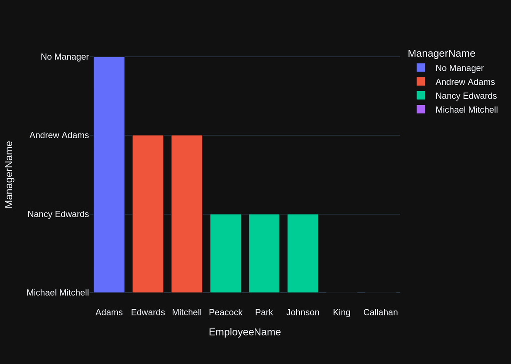

[output not shown]

[output cut: 24 more lines]

[output not shown]

```python
question = """
    List all employees and their reporting manager's name (if any):
"""

vn.ask(question=question)
```

```python
question = """
    Get the average invoice total for each customer:
"""

vn.ask(question=question)
```

```
Number of requested results 10 is greater than number of elements in index 6, updating n_results = 6
Number of requested results 10 is greater than number of elements in index 1, updating n_results = 1
```

```
SQL Prompt: [{'role': 'system', 'content': 'You are a SQLite expert. Please help to generate a SQL query to answer the question. Your response should ONLY be based on the given context and follow the response guidelines and format instructions. \n===Tables \nCREATE TABLE "invoices"\r\n(\r\n    Invoi…
Info: Ollama parameters:
model=phi3:latest,
options={},
keep_alive=None
Info: Prompt Content:
[{"role": "system", "content": "You are a SQLite expert. Please help to generate a SQL query to answer the question. Your response should ONLY be based on the given context and follow the response guidelines and format instructions. \n===Tables \nCREATE TABLE \"invoices\"\r\n(\r\n    InvoiceId INTEG…
Info: Ollama Response:
{'model': 'phi3:latest', 'created_at': '2024-08-01T23:28:15.334569739Z', 'message': {'role': 'assistant', 'content': '-- SQL to find out the average amount on invoices per individual customer, only if they have multiple invoices and at least one of them exceeds $10\nSELECT c.CustomerId, AVG(i.Total)…
LLM Response: -- SQL to find out the average amount on invoices per individual customer, only if they have multiple invoices and at least one of them exceeds $10
SELECT c.CustomerId, AVG(i.Total) AS AverageInvoiceAmount
FROM "customers" c
JOIN "invoices" i ON c.CustomerId = i.CustomerId
WHERE i.Total > 10 AND COUNT(i.InvoiceId) OVER (PARTITION BY c.CustomerId) > 1
GROUP BY c.CustomerId HAVING AVG(i.Total) IS NOT NULL
-- SQL to find out the average amount on invoices per individual customer, only if they have multiple invoices and at least one of them exceeds $10
SELECT c.CustomerId, AVG(i.Total) AS AverageInvoiceAmount
FROM "customers" c
JOIN "invoices" i ON c.CustomerId = i.CustomerId
WHERE i.Total > 10 AND COUNT(i.InvoiceId) OVER (PARTITION BY c.CustomerId) > 1
GROUP BY c.CustomerId HAVING AVG(i.Total) IS NOT NULL
Couldn't run sql:  Execution failed on sql '-- SQL to find out the average amount on invoices per individual customer, only if they have multiple invoices and at least one of them exceeds $10
SELECT c.CustomerId, AVG(i.Total) AS AverageInvoiceAmount
FROM "customers" c
JOIN "invoices" i ON c.CustomerId = i.CustomerId
WHERE i.Total > 10 AND COUNT(i.InvoiceId) OVER (PARTITION BY c.CustomerId) > 1
GROUP BY c.CustomerId HAVING AVG(i.Total) IS NOT NULL': misuse of window function COUNT()
```

```python
question = """
    Find the top 5 most expensive tracks (based on unit price):
"""

vn.ask(question=question)
```

```
Number of requested results 10 is greater than number of elements in index 6, updating n_results = 6
Number of requested results 10 is greater than number of elements in index 1, updating n_results = 1
```

```
SQL Prompt: [{'role': 'system', 'content': 'You are a SQLite expert. Please help to generate a SQL query to answer the question. Your response should ONLY be based on the given context and follow the response guidelines and format instructions. \n===Tables \nCREATE TABLE "tracks"\r\n(\r\n    TrackId…
Info: Ollama parameters:
model=phi3:latest,
options={},
keep_alive=None
Info: Prompt Content:
[{"role": "system", "content": "You are a SQLite expert. Please help to generate a SQL query to answer the question. Your response should ONLY be based on the given context and follow the response guidelines and format instructions. \n===Tables \nCREATE TABLE \"tracks\"\r\n(\r\n    TrackId INTEGER P…
Info: Ollama Response:
{'model': 'phi3:latest', 'created_at': '2024-08-01T23:28:50.507279811Z', 'message': {'role': 'assistant', 'content': 'SELECT TOP 5 * FROM "tracks" ORDER BY UnitPrice DESC; -- for SQL Server dialects that support \'TOP\' keyword, such as Transact-SQL used in Microsoft SQL Server or Sybase. Otherwise:…
LLM Response: SELECT TOP 5 * FROM "tracks" ORDER BY UnitPrice DESC; -- for SQL Server dialects that support 'TOP' keyword, such as Transact-SQL used in Microsoft SQL Server or Sybase. Otherwise:
-- Using LIMIT clause (for MySQL/PostgreSQL):
SELECT * FROM "tracks" ORDER BY UnitPrice DESC LIMIT 5;
Info: Output from LLM: SELECT TOP 5 * FROM "tracks" ORDER BY UnitPrice DESC; -- for SQL Server dialects that support 'TOP' keyword, such as Transact-SQL used in Microsoft SQL Server or Sybase. Otherwise:
-- Using LIMIT clause (for MySQL/PostgreSQL):
SELECT * FROM "tracks" ORDER BY UnitPrice DESC LIMIT 5;
Extracted SQL: SELECT TOP 5 * FROM "tracks" ORDER BY UnitPrice DESC
SELECT TOP 5 * FROM "tracks" ORDER BY UnitPrice DESC
Couldn't run sql:  Execution failed on sql 'SELECT TOP 5 * FROM "tracks" ORDER BY UnitPrice DESC': near "5": syntax error
```

```
Number of requested results 10 is greater than number of elements in index 6, updating n_results = 6
Number of requested results 10 is greater than number of elements in index 1, updating n_results = 1
```

```
SQL Prompt: [{'role': 'system', 'content': 'You are a SQLite expert. Please help to generate a SQL query to answer the question. Your response should ONLY be based on the given context and follow the response guidelines and format instructions. \n===Tables \nCREATE TABLE "tracks"\r\n(\r\n    TrackId…
Info: Ollama parameters:
model=phi3:latest,
options={},
keep_alive=None
Info: Prompt Content:
[{"role": "system", "content": "You are a SQLite expert. Please help to generate a SQL query to answer the question. Your response should ONLY be based on the given context and follow the response guidelines and format instructions. \n===Tables \nCREATE TABLE \"tracks\"\r\n(\r\n    TrackId INTEGER P…
Info: Ollama Response:
{'model': 'phi3:latest', 'created_at': '2024-08-01T23:29:20.193896053Z', 'message': {'role': 'assistant', 'content': '-- SQL to find out how many unique track records exist for each music genre based on GenreId column, along with their names from "genres" table:\nSELECT g.Name as \'Genre\', COUNT(t.…
LLM Response: -- SQL to find out how many unique track records exist for each music genre based on GenreId column, along with their names from "genres" table:
SELECT g.Name as 'Genre', COUNT(t.TrackId) AS NumberOfTracksInGenre
FROM "genres" g
LEFT JOIN tracks t ON g.GenreId = t.GenreId
GROUP BY g.Name
-- SQL to find out how many unique track records exist for each music genre based on GenreId column, along with their names from "genres" table:
SELECT g.Name as 'Genre', COUNT(t.TrackId) AS NumberOfTracksInGenre
FROM "genres" g
LEFT JOIN tracks t ON g.GenreId = t.GenreId
GROUP BY g.Name
                 Genre  NumberOfTracksInGenre
0          Alternative                     40
1   Alternative & Punk                    332
2                Blues                     81
3           Bossa Nova                     15
4            Classical                     74
5               Comedy                     17
6                Drama                     64
7       Easy Listening                     24
8    Electronica/Dance                     30
9          Heavy Metal                     28
10         Hip Hop/Rap                     35
11                Jazz                    130
12               Latin                    579
13               Metal                    374
14               Opera                      1
15                 Pop                     48
16            R&B/Soul                     61
17              Reggae                     58
18                Rock                   1297
19       Rock And Roll                     12
20    Sci Fi & Fantasy                     26
21     Science Fiction                     13
22          Soundtrack                     43
23            TV Shows                     93
24               World                     28
Info: Ollama parameters:
model=phi3:latest,
options={},
keep_alive=None
Info: Prompt Content:
[{"role": "system", "content": "The following is a pandas DataFrame that contains the results of the query that answers the question the user asked: '  \n    List all genres and the number of tracks in each genre:\n'\n\nThe DataFrame was produced using this query: -- SQL to find out how many unique …
Info: Ollama Response:
{'model': 'phi3:latest', 'created_at': '2024-08-01T23:29:48.083782026Z', 'message': {'role': 'assistant', 'content': 'import plotly.graph_objects as go\n\n# Check if DataFrame contains more than one unique genre-track pairing\nif len(df[\'Genre\'].unique()) > 1:\n    fig = go.Figure([go.Bar(x=df[\'G…
```

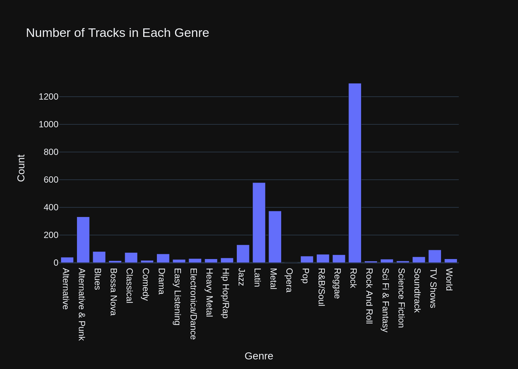

```
('-- SQL to find out how many unique track records exist for each music genre based on GenreId column, along with their names from "genres" table:\nSELECT g.Name as \'Genre\', COUNT(t.TrackId) AS NumberOfTracksInGenre\nFROM "genres" g\nLEFT JOIN tracks t ON g.GenreId = t.GenreId\nGROUP BY g.Name',
                  Genre  NumberOfTracksInGenre
 0          Alternative                     40
 1   Alternative & Punk                    332
 2                Blues                     81
 3           Bossa Nova                     15
 4            Classical                     74
 5               Comedy                     17
 6                Drama                     64
 7       Easy Listening                     24
 8    Electronica/Dance                     30
 9          Heavy Metal                     28
 10         Hip Hop/Rap                     35
 11                Jazz                    130
 12               Latin                    579
 13               Metal                    374
 14               Opera                      1
 15                 Pop                     48
 16            R&B/Soul                     61
 17              Reggae                     58
 18                Rock                   1297
 19       Rock And Roll                     12
 20    Sci Fi & Fantasy                     26
 21     Science Fiction                     13
 22          Soundtrack                     43
 23            TV Shows                     93
 24               World                     28,
 Figure({
     'data': [{'type': 'bar',
               'x': array(['Alternative', 'Alternative & Punk', 'Blues', 'Bossa Nova', 'Classical',
                           'Comedy', 'Drama', 'Easy Listening', 'Electronica/Dance', 'Heavy Metal',
                           'Hip Hop/Rap', 'Jazz', 'Latin', 'Metal', 'Opera', 'Pop', 'R&B/Soul',
                           'Reggae', 'Rock', 'Rock And Roll', 'Sci Fi & Fantasy',
                           'Science Fiction', 'Soundtrack', 'TV Shows', 'World'], dtype=object),
               'y': array([  40,  332,   81,   15,   74,   17,   64,   24,   30,   28,   35,  130,
                            579,  374,    1,   48,   61,   58, 1297,   12,   26,   13,   43,   93,
                             28])}],
     'layout': {'template': '...',
                'title': {'text': 'Number of Tracks in Each Genre'},
                'xaxis': {'title': {'text': 'Genre'}},
                'yaxis': {'title': {'text': 'Count'}}}
 }))
```

```python
question = """
    List all genres and the number of tracks in each genre:
"""

vn.ask(question=question)
```

```python
question = """
    Get all genres that do not have any tracks associated with them:
"""

vn.ask(question=question)
```

```
Number of requested results 10 is greater than number of elements in index 7, updating n_results = 7
Number of requested results 10 is greater than number of elements in index 1, updating n_results = 1
```

```
SQL Prompt: [{'role': 'system', 'content': 'You are a SQLite expert. Please help to generate a SQL query to answer the question. Your response should ONLY be based on the given context and follow the response guidelines and format instructions. \n===Tables \nCREATE INDEX IFK_TrackGenreId ON "tracks"…
Info: Ollama parameters:
model=phi3:latest,
options={},
keep_alive=None
Info: Prompt Content:
[{"role": "system", "content": "You are a SQLite expert. Please help to generate a SQL query to answer the question. Your response should ONLY be based on the given context and follow the response guidelines and format instructions. \n===Tables \nCREATE INDEX IFK_TrackGenreId ON \"tracks\" (GenreId)…
Info: Ollama Response:
{'model': 'phi3:latest', 'created_at': '2024-08-01T23:30:24.254094897Z', 'message': {'role': 'assistant', 'content': '-- SQL to find out which music genres in the database currently don\'t have a track listed underneautically_sql (intermediate query):\nSELECT g.Name as \'Genre without Tracks\' FROM …
LLM Response: -- SQL to find out which music genres in the database currently don't have a track listed underneautically_sql (intermediate query):
SELECT g.Name as 'Genre without Tracks' FROM "genres" g LEFT JOIN tracks t ON g.GenreId = t.GenreId WHERE t.TrackId IS NULL GROUP BY g.Name
-- SQL to find out which music genres in the database currently don't have a track listed underneautically_sql (intermediate query):
SELECT g.Name as 'Genre without Tracks' FROM "genres" g LEFT JOIN tracks t ON g.GenreId = t.GenreId WHERE t.TrackId IS NULL GROUP BY g.Name
Empty DataFrame
Columns: [Genre without Tracks]
Index: []
Info: Ollama parameters:
model=phi3:latest,
options={},
keep_alive=None
Info: Prompt Content:
[{"role": "system", "content": "The following is a pandas DataFrame that contains the results of the query that answers the question the user asked: '  \n    Get all genres that do not have any tracks associated with them:\n'\n\nThe DataFrame was produced using this query: -- SQL to find out which m…
Info: Ollama Response:
{'model': 'phi3:latest', 'created_at': '2024-08-01T23:30:55.407922246Z', 'message': {'role': 'assistant', 'content': 'import plotly.graph_objects as go\n\nif len(df) == 1:\n    trace = go.Indicator(\n        mode=\'number+delta\',\n        number={"value": df[\'Genre without Tracks\'].values[0], "fo…
```

```
('-- SQL to find out which music genres in the database currently don\'t have a track listed underneautically_sql (intermediate query):\nSELECT g.Name as \'Genre without Tracks\' FROM "genres" g LEFT JOIN tracks t ON g.GenreId = t.GenreId WHERE t.TrackId IS NULL GROUP BY g.Name',
 Empty DataFrame
 Columns: [Genre without Tracks]
 Index: [],
 Figure({
     'data': [{'domain': {'x': [0.0, 1.0], 'y': [0.0, 1.0]},
               'hovertemplate': 'Genre without Tracks=%{label}<extra></extra>',
               'labels': array([], dtype=object),
               'legendgroup': '',
               'name': '',
               'showlegend': True,
               'type': 'pie'}],
     'layout': {'legend': {'tracegroupgap': 0}, 'margin': {'t': 60}, 'template': '...'}
 }))
```

```python
question = """
    List all customers who have not placed any orders:
"""

vn.ask(question=question)
```

```
Number of requested results 10 is greater than number of elements in index 7, updating n_results = 7
Number of requested results 10 is greater than number of elements in index 1, updating n_results = 1
```

```
SQL Prompt: [{'role': 'system', 'content': 'You are a SQLite expert. Please help to generate a SQL query to answer the question. Your response should ONLY be based on the given context and follow the response guidelines and format instructions. \n===Tables \nCREATE TABLE "invoices"\r\n(\r\n    Invoi…
Info: Ollama parameters:
model=phi3:latest,
options={},
keep_alive=None
Info: Prompt Content:
[{"role": "system", "content": "You are a SQLite expert. Please help to generate a SQL query to answer the question. Your response should ONLY be based on the given context and follow the response guidelines and format instructions. \n===Tables \nCREATE TABLE \"invoices\"\r\n(\r\n    InvoiceId INTEG…
Info: Ollama Response:
{'model': 'phi3:latest', 'created_at': '2024-08-01T23:31:47.682357856Z', 'message': {'role': 'assistant', 'content': '-- SQL query to find all customers from the \'customers\' table that do not have a corresponding entry in the \'invoices\' (orders) table, assuming there might be no direct link betw…
LLM Response: -- SQL query to find all customers from the 'customers' table that do not have a corresponding entry in the 'invoices' (orders) table, assuming there might be no direct link between customer and order tables if we want to check for non-placeholders. If such an intermediary join is requ…
SELECT c.*
FROM "customers" AS CU
WHERE NOT EXISTS (
    SELECT 1 FROM "invoices" I WHERE I.CustomerId = CU.CustomerId
)
-- SQL query to find all customers from the 'customers' table that do not have a corresponding entry in the 'invoices' (orders) table, assuming there might be no direct link between customer and order tables if we want to check for non-placeholders. If such an intermediary join is required due to mi…
SELECT c.*
FROM "customers" AS CU
WHERE NOT EXISTS (
    SELECT 1 FROM "invoices" I WHERE I.CustomerId = CU.CustomerId
)
Couldn't run sql:  Execution failed on sql '-- SQL query to find all customers from the 'customers' table that do not have a corresponding entry in the 'invoices' (orders) table, assuming there might be no direct link between customer and order tables if we want to check for non-placeholders. If suc…
SELECT c.*
FROM "customers" AS CU
WHERE NOT EXISTS (
    SELECT 1 FROM "invoices" I WHERE I.CustomerId = CU.CustomerId
)': no such table: c
```

```
Number of requested results 10 is greater than number of elements in index 7, updating n_results = 7
Number of requested results 10 is greater than number of elements in index 1, updating n_results = 1
```

````
SQL Prompt: [{'role': 'system', 'content': 'You are a SQLite expert. Please help to generate a SQL query to answer the question. Your response should ONLY be based on the given context and follow the response guidelines and format instructions. \n===Tables \nCREATE TABLE "tracks"\r\n(\r\n    TrackId…
Info: Ollama parameters:
model=phi3:latest,
options={},
keep_alive=None
Info: Prompt Content:
[{"role": "system", "content": "You are a SQLite expert. Please help to generate a SQL query to answer the question. Your response should ONLY be based on the given context and follow the response guidelines and format instructions. \n===Tables \nCREATE TABLE \"tracks\"\r\n(\r\n    TrackId INTEGER P…
Info: Ollama Response:
{'model': 'phi3:latest', 'created_at': '2024-08-01T23:32:28.408447447Z', 'message': {'role': 'assistant', 'content': '-- SQL query to get the top 10 most popular artists in terms of track count:\nSELECT a.Name as \'Artist\', COUNT(t.TrackId) AS TrackCount\nFROM "artists" a\nJOIN "albums" al ON a.Art…
LLM Response: -- SQL query to get the top 10 most popular artists in terms of track count:
SELECT a.Name as 'Artist', COUNT(t.TrackId) AS TrackCount
FROM "artists" a
JOIN "albums" al ON a.ArtistId = al.ArtistId
JOIN "tracks" t ON al.AlbumId = t.AlbumId
GROUP BY a.Name
ORDER BY COUNT(t.TrackId) DESC
LIMIT 10;
Info: Output from LLM: -- SQL query to get the top 10 most popular artists in terms of track count:
SELECT a.Name as 'Artist', COUNT(t.TrackId) AS TrackCount
FROM "artists" a
JOIN "albums" al ON a.ArtistId = al.ArtistId
JOIN "tracks" t ON al.AlbumId = t.AlbumId
GROUP BY a.Name
ORDER BY COUNT(t.TrackId) DESC
LIMIT 10;
Extracted SQL: SELECT a.Name as 'Artist', COUNT(t.TrackId) AS TrackCount
FROM "artists" a
JOIN "albums" al ON a.ArtistId = al.ArtistId
JOIN "tracks" t ON al.AlbumId = t.AlbumId
GROUP BY a.Name
ORDER BY COUNT(t.TrackId) DESC
LIMIT 10
SELECT a.Name as 'Artist', COUNT(t.TrackId) AS TrackCount
FROM "artists" a
JOIN "albums" al ON a.ArtistId = al.ArtistId
JOIN "tracks" t ON al.AlbumId = t.AlbumId
GROUP BY a.Name
ORDER BY COUNT(t.TrackId) DESC
LIMIT 10
            Artist  TrackCount
0      Iron Maiden         213
1               U2         135
2     Led Zeppelin         114
3        Metallica         112
4             Lost          92
5      Deep Purple          92
6        Pearl Jam          67
7    Lenny Kravitz          57
8  Various Artists          56
9       The Office          53
Info: Ollama parameters:
model=phi3:latest,
options={},
keep_alive=None
Info: Prompt Content:
[{"role": "system", "content": "The following is a pandas DataFrame that contains the results of the query that answers the question the user asked: ' \n    There are 3 tables: artists, albums and tracks, where albums and artists are linked by ArtistId, albums and tracks are linked by AlbumId,\n    …
Info: Ollama Response:
{'model': 'phi3:latest', 'created_at': '2024-08-01T23:32:42.963895993Z', 'message': {'role': 'assistant', 'content': "```python\nimport plotly.graph_objs as go\nimport plotly.express as px\n\n# Assuming 'df' is your DataFrame and it has been sorted by TrackCount in descending order already, if not s…
````

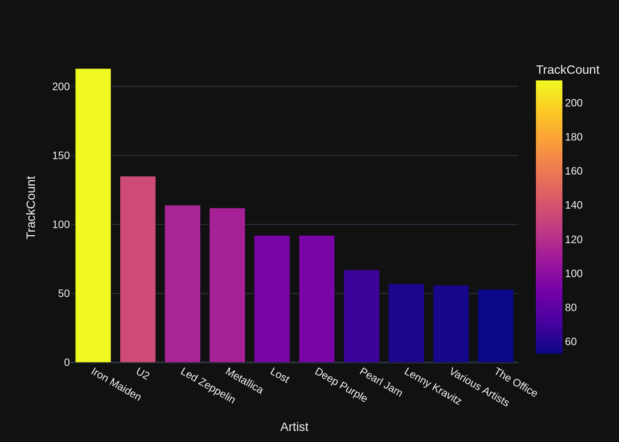

[output not shown]

```python
question = """
    There are 3 tables: artists, albums and tracks, where albums and artists are linked by ArtistId, albums and tracks are linked by AlbumId,
    Can you find the top 10 most popular artists based on the number of tracks
"""

vn.ask(question=question)
```

```
Number of requested results 10 is greater than number of elements in index 8, updating n_results = 8
Number of requested results 10 is greater than number of elements in index 1, updating n_results = 1
```

````
SQL Prompt: [{'role': 'system', 'content': 'You are a SQLite expert. Please help to generate a SQL query to answer the question. Your response should ONLY be based on the given context and follow the response guidelines and format instructions. \n===Tables \nCREATE INDEX IFK_CustomerSupportRepId ON …
Info: Ollama parameters:
model=phi3:latest,
options={},
keep_alive=None
Info: Prompt Content:
[{"role": "system", "content": "You are a SQLite expert. Please help to generate a SQL query to answer the question. Your response should ONLY be based on the given context and follow the response guidelines and format instructions. \n===Tables \nCREATE INDEX IFK_CustomerSupportRepId ON \"customers\…
Info: Ollama Response:
{'model': 'phi3:latest', 'created_at': '2024-08-01T23:33:25.538460717Z', 'message': {'role': 'assistant', 'content': 'SELECT c.Email, Country FROM "customers" c WHERE c.Country LIKE \'Canada\' AND Email IS NOT NULL'}, 'done_reason': 'stop', 'done': True, 'total_duration': 42457951499, 'load_duration…
LLM Response: SELECT c.Email, Country FROM "customers" c WHERE c.Country LIKE 'Canada' AND Email IS NOT NULL
SELECT c.Email, Country FROM "customers" c WHERE c.Country LIKE 'Canada' AND Email IS NOT NULL
                    Email Country
0     ftremblay@gmail.com  Canada
1      mphilips12@shaw.ca  Canada
2     jenniferp@rogers.ca  Canada
3        robbrown@shaw.ca  Canada
4     edfrancis@yachoo.ca  Canada
5    marthasilk@gmail.com  Canada
6  aaronmitchell@yahoo.ca  Canada
7  ellie.sullivan@shaw.ca  Canada
Info: Ollama parameters:
model=phi3:latest,
options={},
keep_alive=None
Info: Prompt Content:
[{"role": "system", "content": "The following is a pandas DataFrame that contains the results of the query that answers the question the user asked: '  \n     List all customers from Canada and their email addresses:\n'\n\nThe DataFrame was produced using this query: SELECT c.Email, Country FROM \"c…
Info: Ollama Response:
{'model': 'phi3:latest', 'created_at': '2024-08-01T23:33:53.5659756Z', 'message': {'role': 'assistant', 'content': '```python\nimport plotly.express as px\nfig = px.bar(df, x=df[\'Country\'], y=\'Email\', color=df[\'Country\'].unique(), barmode=\'group\')\nfig.show()\n``` \nIn this solution, `plotly…
````

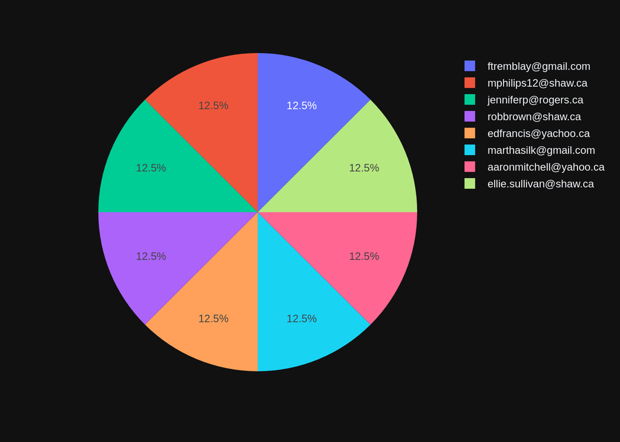

```
('SELECT c.Email, Country FROM "customers" c WHERE c.Country LIKE \'Canada\' AND Email IS NOT NULL',
                     Email Country
 0     ftremblay@gmail.com  Canada
 1      mphilips12@shaw.ca  Canada
 2     jenniferp@rogers.ca  Canada
 3        robbrown@shaw.ca  Canada
 4     edfrancis@yachoo.ca  Canada
 5    marthasilk@gmail.com  Canada
 6  aaronmitchell@yahoo.ca  Canada
 7  ellie.sullivan@shaw.ca  Canada,
 Figure({
     'data': [{'domain': {'x': [0.0, 1.0], 'y': [0.0, 1.0]},
               'hovertemplate': 'Email=%{label}<extra></extra>',
               'labels': array(['ftremblay@gmail.com', 'mphilips12@shaw.ca', 'jenniferp@rogers.ca',
                                'robbrown@shaw.ca', 'edfrancis@yachoo.ca', 'marthasilk@gmail.com',
                                'aaronmitchell@yahoo.ca', 'ellie.sullivan@shaw.ca'], dtype=object),
               'legendgroup': '',
               'name': '',
               'showlegend': True,
               'type': 'pie'}],
     'layout': {'legend': {'tracegroupgap': 0}, 'margin': {'t': 60}, 'template': '...'}
 }))
```

```python
question = """
     List all customers from Canada and their email addresses:
"""

vn.ask(question=question)
```

```python
question = """
     Find the customer with the most invoices
"""

vn.ask(question=question)
```

```
Number of requested results 10 is greater than number of elements in index 9, updating n_results = 9
Number of requested results 10 is greater than number of elements in index 1, updating n_results = 1
```

```
SQL Prompt: [{'role': 'system', 'content': 'You are a SQLite expert. Please help to generate a SQL query to answer the question. Your response should ONLY be based on the given context and follow the response guidelines and format instructions. \n===Tables \nCREATE TABLE "invoices"\r\n(\r\n    Invoi…
Info: Ollama parameters:
model=phi3:latest,
options={},
keep_alive=None
Info: Prompt Content:
[{"role": "system", "content": "You are a SQLite expert. Please help to generate a SQL query to answer the question. Your response should ONLY be based on the given context and follow the response guidelines and format instructions. \n===Tables \nCREATE TABLE \"invoices\"\r\n(\r\n    InvoiceId INTEG…
Info: Ollama Response:
{'model': 'phi3:latest', 'created_at': '2024-08-01T23:34:40.429851838Z', 'message': {'role': 'assistant', 'content': 'SELECT c.FirstName, COUNT(i.InvoiceLineId) AS NumberOfInvoices\nFROM "customers" c JOIN InvoiceLines i ON c.CustomerId = i.CustomerId\nGROUP BY CustomerId\nORDER BY COUNT(i.InvoiceLi…
LLM Response: SELECT c.FirstName, COUNT(i.InvoiceLineId) AS NumberOfInvoices
FROM "customers" c JOIN InvoiceLines i ON c.CustomerId = i.CustomerId
GROUP BY CustomerId
ORDER BY COUNT(i.InvoiceLineId) DESC
LIMIT 1;
Info: Output from LLM: SELECT c.FirstName, COUNT(i.InvoiceLineId) AS NumberOfInvoices
FROM "customers" c JOIN InvoiceLines i ON c.CustomerId = i.CustomerId
GROUP BY CustomerId
ORDER BY COUNT(i.InvoiceLineId) DESC
LIMIT 1;
Extracted SQL: SELECT c.FirstName, COUNT(i.InvoiceLineId) AS NumberOfInvoices
FROM "customers" c JOIN InvoiceLines i ON c.CustomerId = i.CustomerId
GROUP BY CustomerId
ORDER BY COUNT(i.InvoiceLineId) DESC
LIMIT 1
SELECT c.FirstName, COUNT(i.InvoiceLineId) AS NumberOfInvoices
FROM "customers" c JOIN InvoiceLines i ON c.CustomerId = i.CustomerId
GROUP BY CustomerId
ORDER BY COUNT(i.InvoiceLineId) DESC
LIMIT 1
Couldn't run sql:  Execution failed on sql 'SELECT c.FirstName, COUNT(i.InvoiceLineId) AS NumberOfInvoices
FROM "customers" c JOIN InvoiceLines i ON c.CustomerId = i.CustomerId
GROUP BY CustomerId
ORDER BY COUNT(i.InvoiceLineId) DESC
LIMIT 1': no such table: InvoiceLines
```

### Advanced SQL questions

```python
question = """
     Find the customer who bought the most albums in total quantity (across all invoices):
"""

vn.ask(question=question)
```

```
Number of requested results 10 is greater than number of elements in index 9, updating n_results = 9
Number of requested results 10 is greater than number of elements in index 1, updating n_results = 1
```

```
SQL Prompt: [{'role': 'system', 'content': 'You are a SQLite expert. Please help to generate a SQL query to answer the question. Your response should ONLY be based on the given context and follow the response guidelines and format instructions. \n===Tables \nCREATE TABLE "tracks"\r\n(\r\n    TrackId…
Info: Ollama parameters:
model=phi3:latest,
options={},
keep_alive=None
Info: Prompt Content:
[{"role": "system", "content": "You are a SQLite expert. Please help to generate a SQL query to answer the question. Your response should ONLY be based on the given context and follow the response guidelines and format instructions. \n===Tables \nCREATE TABLE \"tracks\"\r\n(\r\n    TrackId INTEGER P…
Info: Ollama Response:
{'model': 'phi3:latest', 'created_at': '2024-08-01T23:35:25.627250868Z', 'message': {'role': 'assistant', 'content': '-- SQL query to find out which customer has spent the highest amount of money on music purchases:\nSELECT c.CustomerName, SUM("invoice_items".Quantity) AS TotalAlbumsBought FROM "Inv…
LLM Response: -- SQL query to find out which customer has spent the highest amount of money on music purchases:
SELECT c.CustomerName, SUM("invoice_items".Quantity) AS TotalAlbumsBought FROM "InvoiceItems" i
JOIN "customers" c ON (i."customerId") = c.CustomerId
GROUP BY CustomerId
ORDER BY COUNT(i.) DESC LIMIT 1;
Info: Output from LLM: -- SQL query to find out which customer has spent the highest amount of money on music purchases:
SELECT c.CustomerName, SUM("invoice_items".Quantity) AS TotalAlbumsBought FROM "InvoiceItems" i
JOIN "customers" c ON (i."customerId") = c.CustomerId
GROUP BY CustomerId
ORDER BY COUNT(i.) DESC LIMIT 1;
Extracted SQL: SELECT c.CustomerName, SUM("invoice_items".Quantity) AS TotalAlbumsBought FROM "InvoiceItems" i
JOIN "customers" c ON (i."customerId") = c.CustomerId
GROUP BY CustomerId
ORDER BY COUNT(i.) DESC LIMIT 1
SELECT c.CustomerName, SUM("invoice_items".Quantity) AS TotalAlbumsBought FROM "InvoiceItems" i
JOIN "customers" c ON (i."customerId") = c.CustomerId
GROUP BY CustomerId
ORDER BY COUNT(i.) DESC LIMIT 1
Couldn't run sql:  Execution failed on sql 'SELECT c.CustomerName, SUM("invoice_items".Quantity) AS TotalAlbumsBought FROM "InvoiceItems" i
JOIN "customers" c ON (i."customerId") = c.CustomerId
GROUP BY CustomerId
ORDER BY COUNT(i.) DESC LIMIT 1': near ")": syntax error
```

```python
question = """
    Hint: album quantity is found in invoice_items,

    Find the top 5 customers who bought the most albums in total quantity (across all invoices):
"""

vn.ask(question=question)
```

```
Number of requested results 10 is greater than number of elements in index 9, updating n_results = 9
Number of requested results 10 is greater than number of elements in index 1, updating n_results = 1
```

```
SQL Prompt: [{'role': 'system', 'content': 'You are a SQLite expert. Please help to generate a SQL query to answer the question. Your response should ONLY be based on the given context and follow the response guidelines and format instructions. \n===Tables \nCREATE TABLE "invoice_items"\r\n(\r\n    …
Info: Ollama parameters:
model=phi3:latest,
options={},
keep_alive=None
Info: Prompt Content:
[{"role": "system", "content": "You are a SQLite expert. Please help to generate a SQL query to answer the question. Your response should ONLY be based on the given context and follow the response guidelines and format instructions. \n===Tables \nCREATE TABLE \"invoice_items\"\r\n(\r\n    InvoiceLin…
Info: Ollama Response:
{'model': 'phi3:latest', 'created_at': '2024-08-01T23:36:06.082551643Z', 'message': {'role': 'assistant', 'content': 'SELECT CustomerName FROM "invoice_lines" iL JOIN "customers" c ON i.CustomerId = c.CustomerId GROUP BY c.CustomerName ORDER BY COUNT(i.InvoiceLineNo) DESC LIMIT 5;'}, 'done_reason': …
LLM Response: SELECT CustomerName FROM "invoice_lines" iL JOIN "customers" c ON i.CustomerId = c.CustomerId GROUP BY c.CustomerName ORDER BY COUNT(i.InvoiceLineNo) DESC LIMIT 5;
Info: Output from LLM: SELECT CustomerName FROM "invoice_lines" iL JOIN "customers" c ON i.CustomerId = c.CustomerId GROUP BY c.CustomerName ORDER BY COUNT(i.InvoiceLineNo) DESC LIMIT 5;
Extracted SQL: SELECT CustomerName FROM "invoice_lines" iL JOIN "customers" c ON i.CustomerId = c.CustomerId GROUP BY c.CustomerName ORDER BY COUNT(i.InvoiceLineNo) DESC LIMIT 5
SELECT CustomerName FROM "invoice_lines" iL JOIN "customers" c ON i.CustomerId = c.CustomerId GROUP BY c.CustomerName ORDER BY COUNT(i.InvoiceLineNo) DESC LIMIT 5
Couldn't run sql:  Execution failed on sql 'SELECT CustomerName FROM "invoice_lines" iL JOIN "customers" c ON i.CustomerId = c.CustomerId GROUP BY c.CustomerName ORDER BY COUNT(i.InvoiceLineNo) DESC LIMIT 5': no such table: invoice_lines
```

```
SELECT c.CustomerId, SUM(il.Quantity) AS TotalAlbums
FROM Customers c
JOIN invoices i  ON c.CustomerId = i.CustomerId
JOIN invoice_items il ON i.InvoiceId = il.InvoiceId
GROUP BY c.CustomerId
ORDER BY TotalAlbums DESC
LIMIT 5
```

```python
question = """
     Find the top 5 customers who spent the most money overall,

     Hint: order total can be found on invoices table, calculation using invoice_items detail table is unnecessary
"""

vn.ask(question=question)
```

```
Number of requested results 10 is greater than number of elements in index 9, updating n_results = 9
Number of requested results 10 is greater than number of elements in index 1, updating n_results = 1
```

```
SQL Prompt: [{'role': 'system', 'content': 'You are a SQLite expert. Please help to generate a SQL query to answer the question. Your response should ONLY be based on the given context and follow the response guidelines and format instructions. \n===Tables \nCREATE TABLE "invoices"\r\n(\r\n    Invoi…
Info: Ollama parameters:
model=phi3:latest,
options={},
keep_alive=None
Info: Prompt Content:
[{"role": "system", "content": "You are a SQLite expert. Please help to generate a SQL query to answer the question. Your response should ONLY be based on the given context and follow the response guidelines and format instructions. \n===Tables \nCREATE TABLE \"invoices\"\r\n(\r\n    InvoiceId INTEG…
Info: Ollama Response:
{'model': 'phi3:latest', 'created_at': '2024-08-01T23:37:03.344369942Z', 'message': {'role': 'assistant', 'content': 'SELECT c.* FROM "customers" c\nJOIN (\n    SELECT o.CustomerId, SUM(i2.Total) AS TotalSpent\n    FROM Invoices i1\n    JOIN InvoicesItems it ON i1.Invoice_id = i2.InvoiceId \n    JOI…
LLM Response: SELECT c.* FROM "customers" c
JOIN (
    SELECT o.CustomerId, SUM(i2.Total) AS TotalSpent
    FROM Invoices i1
    JOIN InvoicesItems it ON i1.Invoice_id = i2.InvoiceId
    JOIN invoice_items i2 on i1.ItemId = i2.TrackId
    GROUP BY o.CustomerId
) AS SpendingTotals s
ON c.CustomerId=c.customerId -- here you are doing the same thing I did before for CustomerID (I'm assuming there is a foreign key from customers to invoices that references it?), but with an additional join, and then just order by desc
ORDER BY TotalSpent DESC LIMIT 5;
Info: Output from LLM: SELECT c.* FROM "customers" c
JOIN (
    SELECT o.CustomerId, SUM(i2.Total) AS TotalSpent
    FROM Invoices i1
    JOIN InvoicesItems it ON i1.Invoice_id = i2.InvoiceId
    JOIN invoice_items i2 on i1.ItemId = i2.TrackId
    GROUP BY o.CustomerId
) AS SpendingTotals s
ON c.CustomerId=c.customerId -- here you are doing the same thing I did before for CustomerID (I'm assuming there is a foreign key from customers to invoices that references it?), but with an additional join, and then just order by desc
ORDER BY TotalSpent DESC LIMIT 5;
Extracted SQL: SELECT c.* FROM "customers" c
JOIN (
    SELECT o.CustomerId, SUM(i2.Total) AS TotalSpent
    FROM Invoices i1
    JOIN InvoicesItems it ON i1.Invoice_id = i2.InvoiceId
    JOIN invoice_items i2 on i1.ItemId = i2.TrackId
    GROUP BY o.CustomerId
) AS SpendingTotals s
ON c.CustomerId=c.customerId -- here you are doing the same thing I did before for CustomerID (I'm assuming there is a foreign key from customers to invoices that references it?), but with an additional join, and then just order by desc
ORDER BY TotalSpent DESC LIMIT 5
SELECT c.* FROM "customers" c
JOIN (
    SELECT o.CustomerId, SUM(i2.Total) AS TotalSpent
    FROM Invoices i1
    JOIN InvoicesItems it ON i1.Invoice_id = i2.InvoiceId
    JOIN invoice_items i2 on i1.ItemId = i2.TrackId
    GROUP BY o.CustomerId
) AS SpendingTotals s
ON c.CustomerId=c.customerId -- here you are doing the same thing I did before for CustomerID (I'm assuming there is a foreign key from customers to invoices that references it?), but with an additional join, and then just order by desc
ORDER BY TotalSpent DESC LIMIT 5
Couldn't run sql:  Execution failed on sql 'SELECT c.* FROM "customers" c
JOIN (
    SELECT o.CustomerId, SUM(i2.Total) AS TotalSpent
    FROM Invoices i1
    JOIN InvoicesItems it ON i1.Invoice_id = i2.InvoiceId
    JOIN invoice_items i2 on i1.ItemId = i2.TrackId
    GROUP BY o.CustomerId
) AS SpendingTotals s
ON c.CustomerId=c.customerId -- here you are doing the same thing I did before for CustomerID (I'm assuming there is a foreign key from customers to invoices that references it?), but with an additional join, and then just order by desc
ORDER BY TotalSpent DESC LIMIT 5': near "s": syntax error
```

```python
question = """
     Get all playlists containing at least 10 tracks and the total duration of those tracks:
"""

vn.ask(question=question)
```

```
Number of requested results 10 is greater than number of elements in index 9, updating n_results = 9
Number of requested results 10 is greater than number of elements in index 1, updating n_results = 1
```

```
SQL Prompt: [{'role': 'system', 'content': 'You are a SQLite expert. Please help to generate a SQL query to answer the question. Your response should ONLY be based on the given context and follow the response guidelines and format instructions. \n===Tables \nCREATE INDEX IFK_PlaylistTrackTrackId ON …
Info: Ollama parameters:
model=phi3:latest,
options={},
keep_alive=None
Info: Prompt Content:
[{"role": "system", "content": "You are a SQLite expert. Please help to generate a SQL query to answer the question. Your response should ONLY be based on the given context and follow the response guidelines and format instructions. \n===Tables \nCREATE INDEX IFK_PlaylistTrackTrackId ON \"playlist_t…
Info: Ollama Response:
{'model': 'phi3:latest', 'created_at': '2024-08-01T23:37:39.924205661Z', 'message': {'role': 'assistant', 'content': 'SELECT PlaylistName, COUNT(PlaylistId) AS TotalSongsIncluded FROM "playlists" GROUPBY \'Tracks\' As Num_OfTrack WHERE TrackType = \'album\';'}, 'done_reason': 'stop', 'done': True, '…
LLM Response: SELECT PlaylistName, COUNT(PlaylistId) AS TotalSongsIncluded FROM "playlists" GROUPBY 'Tracks' As Num_OfTrack WHERE TrackType = 'album';
Info: Output from LLM: SELECT PlaylistName, COUNT(PlaylistId) AS TotalSongsIncluded FROM "playlists" GROUPBY 'Tracks' As Num_OfTrack WHERE TrackType = 'album';
Extracted SQL: SELECT PlaylistName, COUNT(PlaylistId) AS TotalSongsIncluded FROM "playlists" GROUPBY 'Tracks' As Num_OfTrack WHERE TrackType = 'album'
SELECT PlaylistName, COUNT(PlaylistId) AS TotalSongsIncluded FROM "playlists" GROUPBY 'Tracks' As Num_OfTrack WHERE TrackType = 'album'
Couldn't run sql:  Execution failed on sql 'SELECT PlaylistName, COUNT(PlaylistId) AS TotalSongsIncluded FROM "playlists" GROUPBY 'Tracks' As Num_OfTrack WHERE TrackType = 'album'': near "'Tracks'": syntax error
```

```python
question = """
     Identify artists who have albums with tracks appearing in multiple genres:


"""

vn.ask(question=question)
```

```
Number of requested results 10 is greater than number of elements in index 9, updating n_results = 9
Number of requested results 10 is greater than number of elements in index 1, updating n_results = 1
```

[output not shown]

[output cut: 26 more lines]

[output not shown]

### Check completion time

```python
from datetime import datetime
```

```python
ts_stop = time()
elapsed_time = ts_stop - ts_start
```

```python
print(f"[{datetime.now()}] test on '{hostname}' with '{model_name}' LLM took : {elapsed_time:.2f} sec")
```

```
[2024-08-03 01:47:36.352596] test on 'ducklover1' with 'phi3' LLM took : 1185.90 sec
```

```python
!pwd
```

```
/home/gongai/projects/1_Biz/vanna/note_book/gongai/test-2
```

[output not shown]

## Launch the User Interface

[figure not shown]

## Next Steps

Using Vanna via Jupyter notebooks is great for getting started but check out additional customizable interfaces like the

- [Streamlit app](https://github.com/vanna-ai/vanna-streamlit)
- [Flask app](https://github.com/vanna-ai/vanna-flask)
- [Slackbot](https://github.com/vanna-ai/vanna-slack)